# The Topic and Research Question

How to Find a Topic and a Research Question

Bogdan G. Popescu

bogdan.popescu@johncabot.edu

John Cabot University

## Table of Contents

1. From Curiosity to Topic
2. Topic vs. Research Question
3. Finding and Exploring the Literature
4. Crafting a Strong Research Question
5. Evaluating Your Question: Why It Matters

## Organization

Before we delve into how to find a question or how to find a topic, we need to organize our space.

Create a folder called “project_x” with the following subfolders (you will change the “x” to a relevant keyword later).

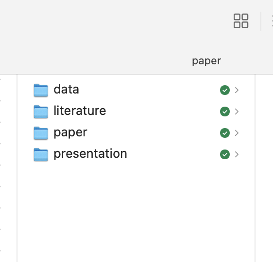

## Topic vs. Question

We will distinguish between:

- **Topic**: a broad area or theme you’re interested in studying
- **Research Question**: a specific, focused question that helps you investigate something within that topic

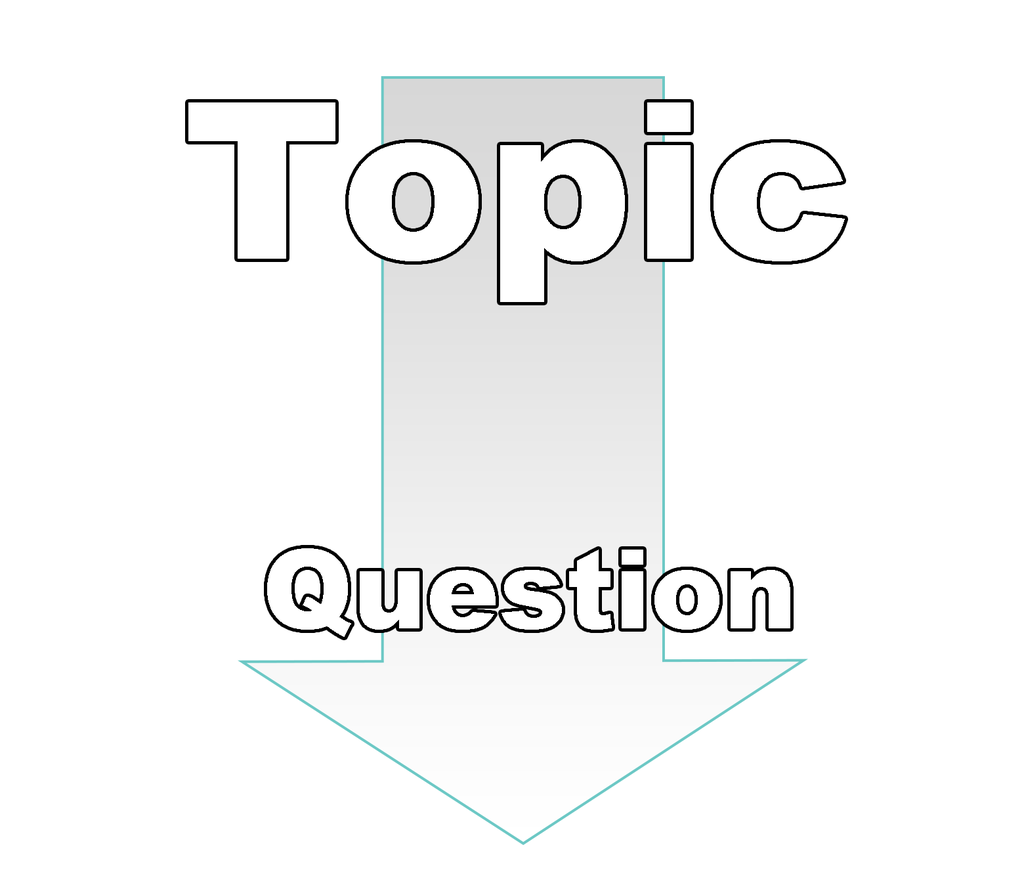

## Research Topic

### Intro

A research topic comes from:

- your curiosity (influenced by events and processes around us)
- the events, issues, or processes we observe in the world around us
- the theories and frameworks that you have read (ideally in the academic literature)

## Choosing a Topic

### How To Find a Topic

1. What’s a big question you’ve always wondered about?
2. What’s something people always argue about that you’d like to understand better?

Note: the question should be relevant (present in the news).

3. See what topics have been published in the leading journals in the last two years

## Choosing a Topic

### How To Find a Topic

These are topics (and subtopics) that have been published in *American Journal of Political Science* since Jan 2024

1. **Democratic Backsliding and Political Legitimacy**
- Citizens as a democratic safeguard
- Populism, legitimacy, and the law
2. **Identity, Ethnicity, and Conflict**
- Administrative units shape ethnic identity
- Colonial legacies and ethnic party formation

## Choosing a Topic

### How To Find a Topic

These are topics (and subtopics) that have been published in *American Journal of Political Science* since Jan 2024

3. **Experimental Methods and Policy Interventions**
- Citizen engagement and Public goods
- Gender quotas and electoral backlash
4. **Global South and Postcolonial Politics**
- The colonial origins of intergroup inequality
- The subnational politics of repression in Africa

## Choosing a Topic

### Advice

1. Am I excited to spend time thinking and writing about it?
2. Start broad and narrow down as you read more.
3. Avoid using AI to generate your topic — this should come from your own curiosity and from the constraints (topics published recently) indicated

**Example**:

- **Big Topic**: climate change
- **Narrower Topic**: youth activism and climate change
- **Question**: how TikTok is used to spread climate change awareness among teens

## Choosing a Topic

### Exercise 1

Spend 5 minutes coming up with a topic based on specific curiosity questions (not research questions)

Example:

## Choosing a Topic

### Exercise 2: Making the Topic Yours

Circle 2-3 questions that most interest you.

When you circle them, spend 5 minutes writing 1–2 sentences for each of the following questions:

- Why does this matter to me?
- What do I think is true about this?
- What aspect of the problems do I want to know more about?

## Choosing a Topic

### Exercise 2: Making the Topic Yours

**Example: Q4: Do gender quotas produce backlash from men in parliaments? → Political Representation and Rhetoric**

**1. Why does this matter to me?**

Because it reveals how efforts to improve representation can unintentionally provoke resistance from those who feel their power is threatened. Understanding that backlash helps explain why progress on gender equality is often uneven or fragile.

**2.What do I think is true about this?**

I think it’s true that some men respond defensively to gender quotas—not just out of self-interest, but because they view them as unfair or symbolic rather than merit-based.

**3. What aspect of the problem do I want to know more about?**

I want to understand how backlash manifests—whether it affects legislative behavior, cooperation, or public rhetoric—and whether it can be mitigated through institutional design or framing strategies.

## Topic

### Finding the Topic

The topic may also potentially change once you become a bit more familiar with the literature.

The next step will be to join an **intellectual conversation** by becoming familiar with the literature

We will have a dedicated session later for how to do a literature review.

## Finding the Topic

### To Do

**Make a list of articles that are close to your personal interest.**

After clarifying why your topic matters to you, the next step is to find out how other scholars have approached it.

- Search online (Google Scholar) for 3 articles directly related to your topic.
- Type in the two factors you might be interested in. For example:
  - “youth activism and climate change”
  - “citizen participation and democratic backsliding”
  - “colonial legacies and quality of bureaucracy”
  - “gender quotas and political rhetoric”

## Finding the Topic

### Example

Let’s imagine I am interested in “gender quotas and political rhetoric”

[figure not shown]

## Finding the Topic

### Example

Let’s imagine I am interested in “gender quotas and political rhetoric”

[figure not shown]

## Finding the Topic

### Example

Let’s imagine I am interested in “gender quotas and political rhetoric”

[figure not shown]

## Finding the Topic

### Example

Choose based on:

- **relevance** (how close it is to what interests you)
- **citations** (indicator for how popular the scholar’s work is)
- **source type** (favor peer-reviewed publications like “Journal of …”)

[figure not shown]

## Finding the Topic

### Example

Save the pdfs to the literature folder using the following format:

Use a format like: lastname_year_shorttitle.pdf  
(e.g., simpser_2012_turnout.pdf)

See below for an example:

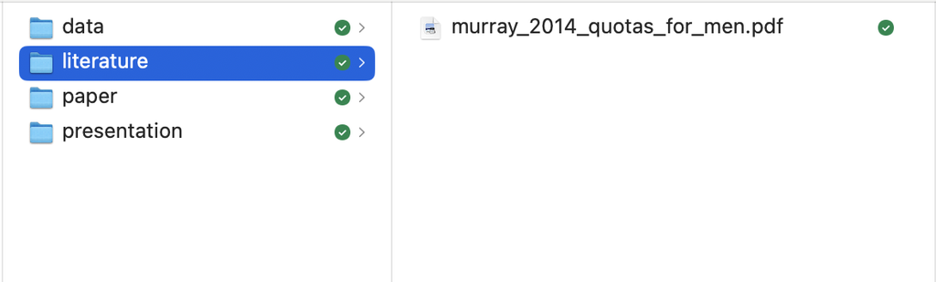

## Finding the Topic

### Example

What if the documents in Google Scholar are irrelevant or inaccessible?

- keep looking at Google Scholar both based on **relevance**, **number of citations**, and **source type** (where you favor journal articles as opposed to IMF reports or newspaper articles) until you have three documents

## Finding the Topic

### To Do: Highlighting

- Spend 5 minutes and go through the three abstracts:
  - **highlight the verbs** and **key phrases** that indicate what the authors are asserting
- If the articles are not close to what you had in mind, keep looking until you have 3 articles

## Finding the Topic

### To Do: Highlighting

Example: Key Verbs - in yellow; Key Phrases - in red

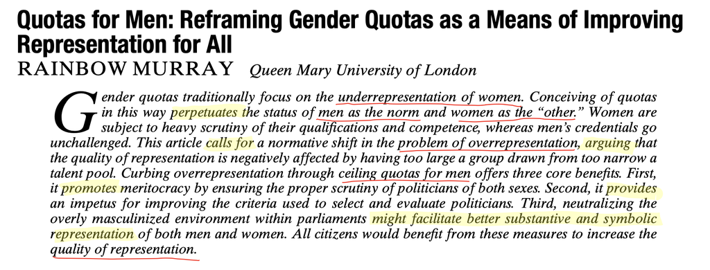

## Finding the Topic

### Reflection: To Do

**The authors are your interlocutors. To start a conversation, spend 10 minutes answering the following questions (2-3 sentences per question)**

- Do you agree or disagree with their main conclusion? Why?
- What questions do you still have after reading the abstracts?
- What do you want to say to them and why is it important to say that?
- Why does the topic chosen matter to you?

## Finding the Topic

### Reflection: To Do

**Example:**

**Do you agree or disagree with their main conclusion? Why?**

*Agree*. Reframing quotas to address men’s overrepresentation challenges the assumption that men are the default and promotes a more balanced standard for evaluating all candidates. It’s a provocative but necessary shift to make meritocracy truly inclusive.

**What questions do you still have after reading the abstract?**

- How would ceiling quotas for men be implemented without backlash or unintended consequences?
- Do they have empirical evidence that overrepresentation leads to lower-quality politicians?

**What do you want to say to them and why is it important to say that?**

Great that the authors are flipping the script. By naming overrepresentation, they expose a power structure that’s rarely questioned. It’s important because it forces us to rethink fairness not just as inclusion but also as limitation.

## Finding the Topic

### Reflection: To Do

**Example:**

**Why does the topic chosen matter to you?**

It matters because it challenges how we define excellence and fairness in politics. The idea that merit is already gendered makes me rethink the legitimacy of who holds power—and who is excluded.

## Finding the Topic

### Recap

What have we done so far?

- Chosen a topic
- Clarified why it matters
- Found 3 related articles
- Reflected on existing arguments

You’re now ready to move from topic → **research question.**

## Research Question

### Definition

A research question is something more narrow than a topic.

- the research question has to be **important**
- the question should **not have been answered before** (it should stem from some gap)
- the question has to be **researchable**:
  - can you access people, statistics, or documents from which to collect the data?
  - can this data be accessed within the limited time and resources you have available to you?
  - How long would you need to complete the research necessary to answer the question?

## Bad Questions

### Examples

Example 1:

**Is the US winning its “War on Terror”?**

- important question
- too broad to be researched

Better version:

**What has been the impact of the securitization of Muslim charities in Egypt since 9/11?**

- still important
- specific

## Bad Questions

### Examples

Example 2:

**“Does globalization undermine the basis of the nation state?**

- important question
- too broad to be researched

Better version:

“What impact does economic integration have on state autonomy?  
Do high levels of integration into the world economy decrease a state’s ability to manage its public finances?”

- still important
- specific

## Other Bad Questions

### Examples

**How did the Cold War end?**

- overly descriptive
- does not have an exploratory angle

**Does politics affect the economy?**

- too vague
- the answer is too obvious (i.e. “yes”)

**Will there be peace in the Middle East?**

- it’s speculative and journalistic
- there is no theoretical framing

## Good Questions

### Examples

**Explanatory**

- What factors act as a stimulus or facilitator to terrorism?
- Why Do Some Post-Authoritarian States Succeed in Building Independent Judiciaries While Others Do Not?
- Why Do Civil Conflicts Reignite After Peace Agreements in Some Cases but Not Others?

## Good Questions

### Characteristics

What makes them good?

- Identify a **clear outcome** to explain (judicial independence, civil conflict recurrence, terrorism)
- Imply **causal mechanisms**: They’re asking why variation exists across cases, inviting theory development.
- Are **researchable**: You can define measurable variables, collect data, and test theories.

## Okay-ish Questions

**Predictive**

- Will the Spread of Disinformation Undermine Electoral Legitimacy in Emerging Democracies?
- Can Declining Trust in Traditional Media Predict Support for Populist Parties?

**Descriptive**

- What are the consequences of AI for politics?
- How will different audiences react to terrorism?
- What type of individual becomes a terrorist?

**Prescriptive**

- Can political violence be justified?
- How can governments respond to terrorism?

## Okay-ish Questions

| Category | Typical Shortcoming | Why It’s “Okay-ish” |
| --- | --- | --- |
| Predictive | May lack causal theory | Good forecasting ≠ good explanation |
| Descriptive | Lacks causal argument or theory | Describes patterns but doesn’t explain them |
| Prescriptive | Normative not empirical | Can’t be tested empirically in standard ways |

Note Bene: These questions can become good, but more work needs to be done to convince the reader that these are good research questions

## Research Question

### Coming up with a Research Question: To Do

Spend 5 minutes coming up with three research questions based on the topic you identified.

**Examples**:

1. How do gender quotas affect the tone of parliamentary rhetoric by male politicians?
2. Do gender quotas lead to shifts in how male politicians frame issues related to gender and representation?
3. Do gender quotas increase the use of gendered or exclusionary language in legislative debates?

## Research Question

### The Rationale

After you come up with a research question, you also need to reflect on:

- why is your question interesting (without clearly stating: “My question is interesting because”)
- why is it important: why does it matter?

## Research Question

### The Rationale: To Do

Try writing a sentence that starts with, “This finding is important because…”

What are some possible reasons a reader would care about your article?

- You substantiate an existing theory in your field.
- You take a side in a debate in your field.
- Your findings contradict conventional wisdom.
- You show that both sides of the debate have it wrong and propose an alternative.
- You provide an answer (not the answer) to an enduring question in your field.

## Research Question

### The Rationale: To Do

**Example**

**Why is your question interesting (without clearly stating: “My question is interesting because”)**

Gender quotas are designed to change who gets a seat at the table, but they may also reshape how power is expressed once everyone is seated. Exploring how male politicians adjust their rhetorical style in response offers a lens into the subtle, often hidden, dynamics of resistance and adaptation within political institutions.

**Why is it important: why does it matter?**

It can reveal how institutional reforms can reshape not just who participates in politics, but how they engage with each other rhetorically.

## Research Question

### The Gap

This information is similar what we discuss in the literature review

The research question will be rewritten after identifying the **gap** in the literature

Identifying the gap makes your question derive more naturally from the literature.

## Research Question

### Feasibility Check

Ask yourself:

- Can I find data or documents on this?
- Can I do this in the allocated time?
- Will I need access to fieldwork or hard-to-reach respondents?

**Common Pitfalls**

- Choosing a topic that’s too recent and lacks literature.
- Trying to solve a normative issue without empirical tools.
- Selecting a topic just because it sounds “cool” but not feasible.

## Conclusion

### Takeaway: From Curiosity to Research Question

Finding a research question is typically harder than finding a topic.

Your research question will change slightly as you read more.

Your research question will also change as you work through the different components of the article: methodology, analysis, conclusion

## Homework

### Answer the Following Questions in a Word Document

1. Search for Related Literature. Use Google Scholar to find 3 articles directly related to your topic. Search for combinations of two key concepts (e.g. “gender quotas and political rhetoric”).
2. Organize and Save the PDFs. Save PDFs using this format: `authorlastname_year_title_keywords.pdf.` Place them in the “literature” subfolder. No need to type anything here
3. Highlight Key Ideas. Spend 5 minutes going through each abstract. Highlight key verbs and phrases about what the authors are asserting. No need to type anything here

4.a Do you agree or disagree with their main conclusion? Why?  
4.b What questions do you still have after reading the abstracts?  
4.c What do you want to say to them and why is it important to say that?  
4.d Why does the topic chosen matter to you?

5. Based on your topic, write 3 research questions. Make sure they are specific, causal (if possible), and researchable.
6. What is the rationale for your research question? Why is your question interesting (without clearly stating: “My question is interesting because”). Why is it important: why does it matter?